# Lista 2 — Respostas

Probabilidade e Estatística – 2020.1

fnaufel

Criado em 07/12/2020 Versão de 22/09/2021

# 1 Distância entre bancos

- Segundo o [Levantamento do Perfil Antropométrico da População Brasileira Usuária do Transporte Aéreo Nacional](https://www2.anac.gov.br/arquivos/pdf/Relatorio_Final_Projeto_Conhecer.pdf), de 2009, a distância glúteo-joelho (ver figura abaixo) do homem brasileiro segue uma distribuição normal com média $\mu = 60{,}7$cm e desvio padrão $\sigma = 3{,}1$cm.

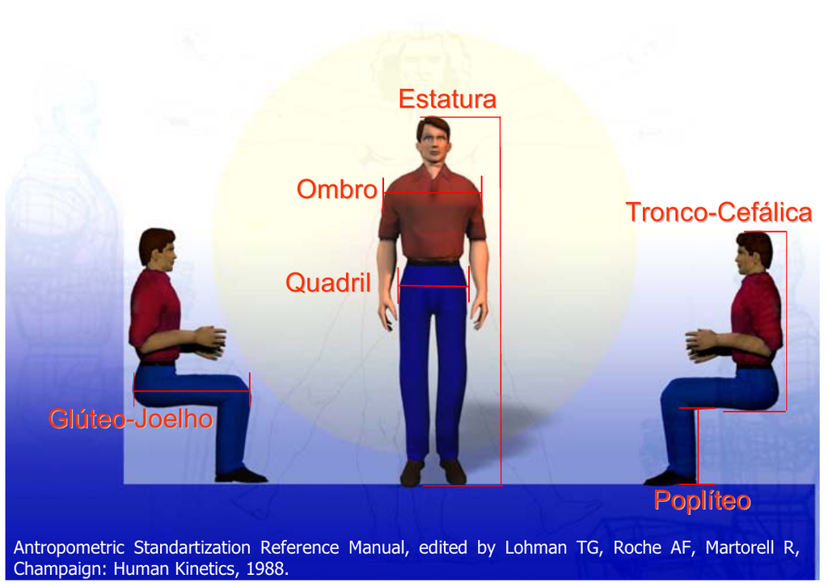

  Em um avião, qual deve ser a distância mínima entre a parte dianteira do encosto de uma poltrona (onde encosta o glúteo) e a parte traseira da poltrona imediatamente à frente (onde encosta o joelho) para que $95\%$ dos homens brasileiros possam caber sentados conforme a figura abaixo?

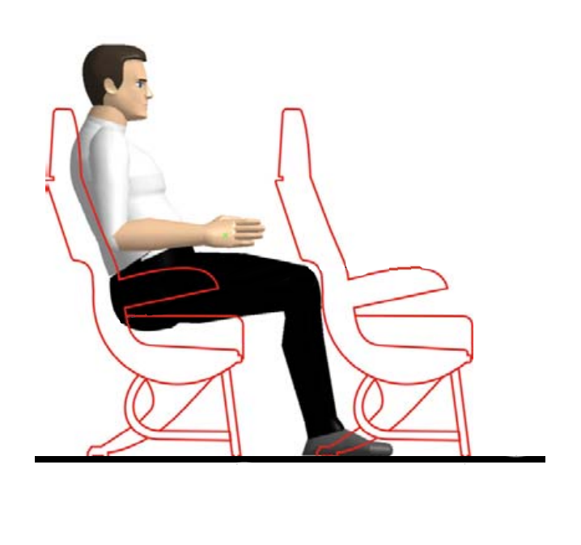

### Solução

```r
mu <- 60.7
sigma <- 3.1
p <- .95

q <- qnorm(p, mu, sigma)
q
```

```
## [1] 65,79905
```

A distância deve ser de $65{,}80$cm.

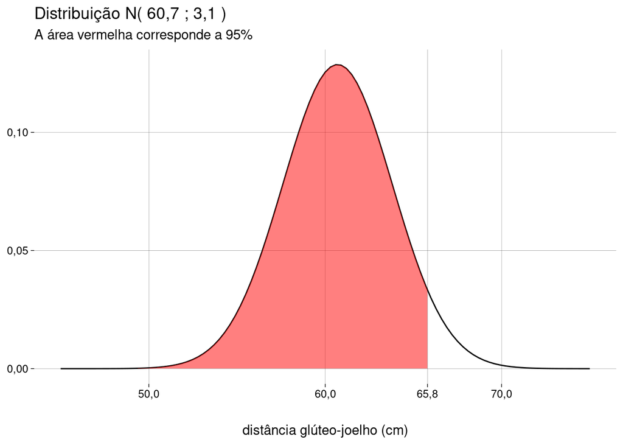

```r
ggplot() +
  stat_function(
    fun = dnorm,
    args = c(mu, sigma)
  ) +
  stat_function(
    fun = dnorm,
    args = c(mu, sigma),
    xlim = c(45, q),
    geom = 'area',
    fill = 'red',
    alpha = .5
  ) +
  scale_x_continuous(
    limits = c(45, 75),
    breaks = c(50, 60, 70, q %>% round(2))
  ) +
  labs(
    y = NULL,
    x = 'distância glúteo-joelho (cm)',
    title = paste('Distribuição N(', mu, ';', sigma, ')'),
    subtitle = 'A área vermelha corresponde a 95%'
  )
```

# 2 Caixa de mercado

- Em um caixa de um pequeno mercado, o número de clientes que chegam por minuto é, em média, $4$.
- Vamos representar este número pela variável aleatória $X$, com suporte $\{ 0, 1, 2, 3, \ldots \}$.
- As chegadas dos clientes são independentes umas das outras.
- Se você dividir o tempo em intervalos menores do que um minuto, a média se mantém: $2$ clientes a cada $30$ segundos, $1$ cliente a cada $15$ segundos etc.
- Clientes diferentes não chegam ao caixa no mesmo instante.
- Então, a variável aleatória $X$ segue a distribuição de Poisson, com média $\lambda = 4$.
- Faça uma simulação:
  1. Usando `rpois`, gere uma amostra de $60$ números, correspondendo a $1$ hora de funcionamento do caixa.
  2. Escreva uma função em R para processar esta amostra e retornar um vetor de $60$ elementos: a quantidade de clientes na fila ao final de cada minuto (de $1$ a $60$). Lembre-se de que o caixa processa $4$ clientes por minuto.
  3. Faça um gráfico do número de clientes na fila ao final de cada minuto, ao longo do tempo.
  4. Usando `rpois`, agora gere uma amostra de $60$ números, correspondendo a $1$ hora de funcionamento do caixa, desta vez com uma média de $5$ clientes chegando por minuto.
  5. Use a função que você escreveu para processar esta amostra e retornar um vetor com a quantidade de clientes na fila a cada minuto (de $1$ a $60$), *supondo que o caixa ainda processa só $4$ clientes por minuto*.
  6. Faça um gráfico do número de clientes na fila ao final de cada minuto, ao longo do tempo.

### Solução

1. Usando `rpois`, gere uma amostra de $60$ números, correspondendo a $1$ hora de funcionamento do caixa.

   ```r
   lambda <- 4
   minutos <- 60
   amostra1 <- rpois(n = minutos, lambda = lambda)
   amostra1
   ```

   ```
   ##  [1]  2  4  4  4  6  5  0  2  5  4  5  4  3  7  3  6  3  3  2  2  3  3  2  1  2
   ## [26]  6  4  7  6  1  4  3  3  4  2  5  2  3 10  6  4  5  3  4  3  4  5  4  3  5
   ## [51]  1  3  5  4  2  4  4  5  2  6
   ```

2. Escreva uma função em R para processar esta amostra e retornar um vetor de $60$ elementos: a quantidade de clientes na fila ao final de cada minuto (de $1$ a $60$). Lembre-se de que o caixa processa $4$ clientes por minuto.

   ```r
   fila <- function(amostra, capacidade) {

     n <- length(amostra)
     sobra <- vector(mode = 'numeric', n)

     anterior <- 0

     for (i in 1:n) {

       sobra[i] <- amostra[i] + anterior - capacidade
       sobra[i] <- ifelse(sobra[i] < 0, 0, sobra[i])
       anterior <- sobra[i]

     }

     sobra

   }
   ```

   ```r
   capacidade = 4
   fila1 <- fila(amostra1, capacidade)
   fila1
   ```

   ```
   ##  [1] 0 0 0 0 2 3 0 0 1 1 2 2 1 4 3 5 4 3 1 0 0 0 0 0 0 2 2 5 7 4 4 3 2 2 0 1 0 0
   ## [39] 6 8 8 9 8 8 7 7 8 8 7 8 5 4 5 5 3 3 3 4 2 4
   ```

3. Faça um gráfico do número de clientes na fila ao final de cada minuto, ao longo do tempo.

   Decidi incluir as chegadas no gráfico, plotando cada elemento no minuto anterior.

   ```r
   graf_fila <- function(chegadas, fila) {

     n <- length(chegadas)

     maior_x <- n
     intervalo_x <- 10^ceiling(log(maior_x, base = 10) - 1)
     breaks_x <- seq(0, maior_x, intervalo_x)

     maior_y <- max(max(chegadas), max(fila))
     intervalo_y <- 10^ceiling(log(maior_y, base = 20) - 1)
     breaks_y <- seq(0, maior_y, intervalo_y)

     tibble(chegadas, fila) %>%
       ggplot(aes(1:n, fila)) +
         geom_point(aes(color = 'esperando'), size = 2) +
         geom_line(aes(color = 'esperando'), size = 1) +
         geom_point(
           aes(x = 0:(n-1), y = chegadas, color = 'chegadas')
         ) +
         geom_line(
           aes(x = 0:(n-1), y = chegadas, color = 'chegadas')
         ) +
         labs(
           x = 'minuto',
           y = 'pessoas',
           color = NULL
         ) +
         scale_x_continuous(breaks = breaks_x) +
         scale_y_continuous(breaks = breaks_y)

   }
   ```

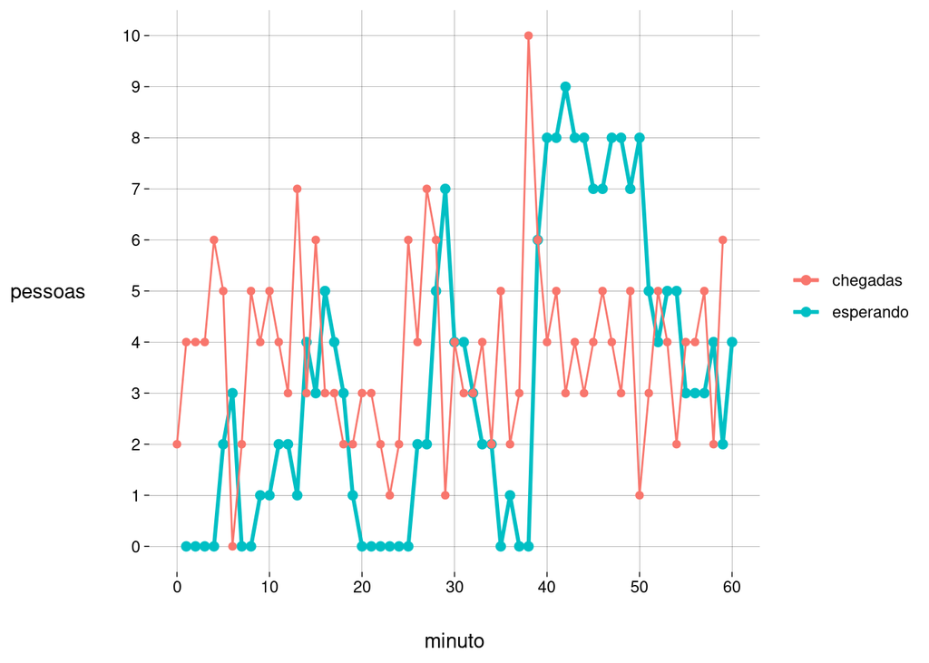

   ```r
   graf_fila(amostra1, fila1)
   ```

4. Usando `rpois`, agora gere uma amostra de $60$ números, correspondendo a $1$ hora de funcionamento do caixa, desta vez com uma média de $5$ clientes chegando por minuto.

   ```r
   lambda <- 5
   amostra2 <- rpois(n = minutos, lambda = lambda)
   amostra2
   ```

   ```
   ##  [1] 7 2 4 1 3 6 4 5 2 5 2 8 1 7 2 5 4 2 4 6 8 5 3 5 3 8 4 4 3 8 3 8 3 3 2 5 4 1
   ## [39] 4 6 1 5 4 3 3 4 3 3 4 1 6 2 9 2 3 8 9 4 2 7
   ```

5. Use a função que você escreveu para processar esta amostra e retornar um vetor com a quantidade de clientes na fila a cada minuto (de $1$ a $60$), *supondo que o caixa ainda processa só $4$ clientes por minuto*.

   ```r
   capacidade = 4
   fila2 <- fila(amostra2, capacidade)
   fila2
   ```

   ```
   ##  [1]  3  1  1  0  0  2  2  3  1  2  0  4  1  4  2  3  3  1  1  3  7  8  7  8  7
   ## [26] 11 11 11 10 14 13 17 16 15 13 14 14 11 11 13 10 11 11 10  9  9  8  7  7  4
   ## [51]  6  4  9  7  6 10 15 15 13 16
   ```

6. Faça um gráfico do número de clientes na fila ao final de cada minuto, ao longo do tempo.

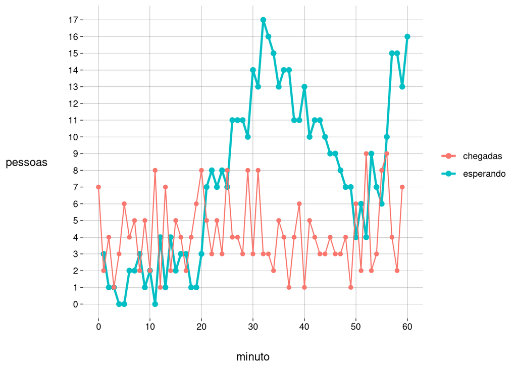

   ```r
   graf_fila(amostra2, fila2)
   ```

#### Curioso?

E se deixássemos o tempo correr mais? $16$ horas, por exemplo.

- $\lambda = 4$:

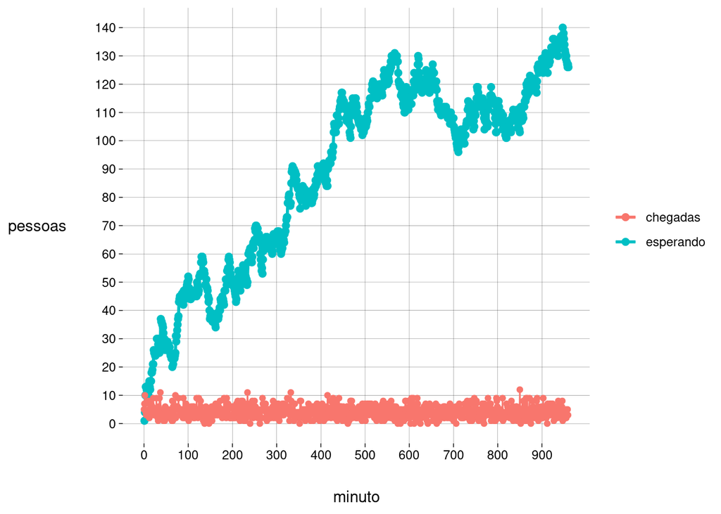

  ```r
  lambda <- 4
  minutos <- 60 * 16
  amostra <- rpois(n = minutos, lambda = lambda)

  capacidade = 4
  sobram <- fila(amostra, capacidade)
  graf_fila(amostra, sobram)
  ```

- $\lambda = 5$:

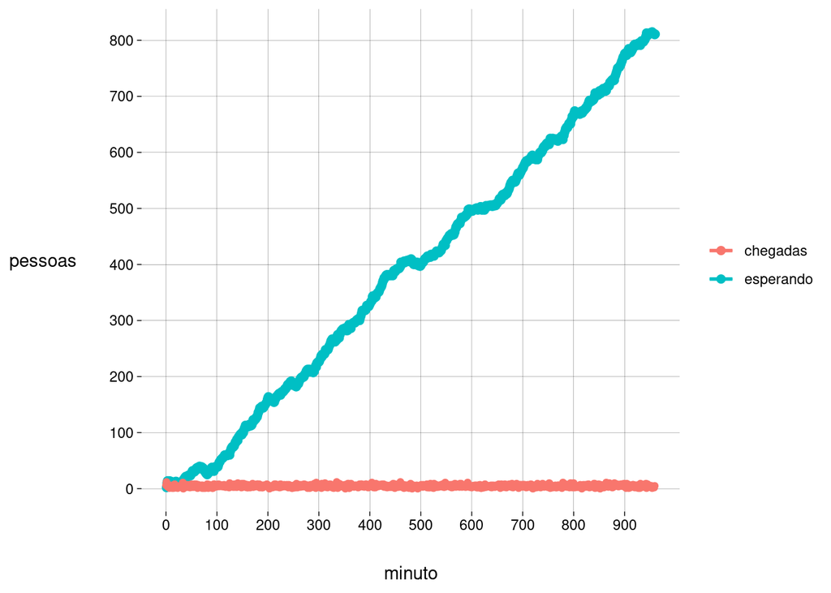

  ```r
  lambda <- 5
  minutos <- 60 * 16
  amostra <- rpois(n = minutos, lambda = lambda)

  capacidade = 4
  sobram <- fila(amostra, capacidade)
  graf_fila(amostra, sobram)
  ```

# 3 Pessoas canhotas

- Na população, $12\%$ das pessoas são canhotas.
- Você escolhe $100$ pessoas ao acaso.
- Em relação ao grupo de pessoas escolhidas:
  1. Qual é a média e o desvio padrão da variável aleatória que representa o número de pessoas destras no grupo?
  2. Qual é a probabilidade de nem todas as pessoas do grupo serem canhotas?
  3. Qual é a probabilidade de haver no máximo $75$ pessoas destras no grupo?
  4. Qual é a probabilidade de a maioria das pessoas do grupo serem destras?

### Solução

- Vamos decidir que $X$ vai ser a variável aleatória que representa o número de *pessoas destras*.
- A distribuição de $X$ vai ser a binomial. Cada pessoa é uma prova, com probabilidade de sucesso — i.e., de ser destra — de $p = 1 - 0{,}12 = 0{,}88$.
- Nossa amostra tem $100$ pessoas. Então, $n = 100$.
- Escrevemos
  $$X \sim \text{Binom}(n = 100, p = 0{,}88)$$
1. Qual é a média e o desvio padrão da variável aleatória que representa o número de pessoas destras no grupo?

   Na distribuição binomial, a média é
   $$n \cdot p = 100 \cdot 0{,}88 = 88$$
   e o desvio padrão é
   $$\sqrt{n \cdot p \cdot (1 - p)} = \sqrt{100 \cdot 0{,}88 \cdot 0{,}12} = 3{,}25$$
2. Qual é a probabilidade de nem todas as pessoas do grupo serem canhotas?

   Como $X$ é o número de destros, queremos $P(X > 0)$, que é igual a $1 - P(X = 0$. A probabilidade de haver zero destros é um número ínfimo:

   ```r
   n <- 100
   p <- .88
   zero_destros <- pbinom(q = 0, size = n, prob = p)
   zero_destros
   ```

   ```
   ## [1] 8,281797e-93
   ```

   ```r
   1 - zero_destros
   ```

   ```
   ## [1] 1
   ```

   Podíamos ter obtido a resposta diretamente, usando

   ```r
   pbinom(q = 0, size = n, prob = p, lower.tail = FALSE)
   ```

   ```
   ## [1] 1
   ```

3. Qual é a probabilidade de haver no máximo $75$ pessoas destras no grupo?

   ```r
   pbinom(q = 75, size = n, prob = p)
   ```

   ```
   ## [1] 0,0002567994
   ```

4. Qual é a probabilidade de a maioria das pessoas do grupo serem destras?

   A maioria é um número maior que $50$:

   ```r
   pbinom(q = 50, size = n, prob = p, lower.tail = FALSE)
   ```

   ```
   ## [1] 1
   ```

   De novo, uma probabilidade altíssima.

#### Como é esta distribuição?

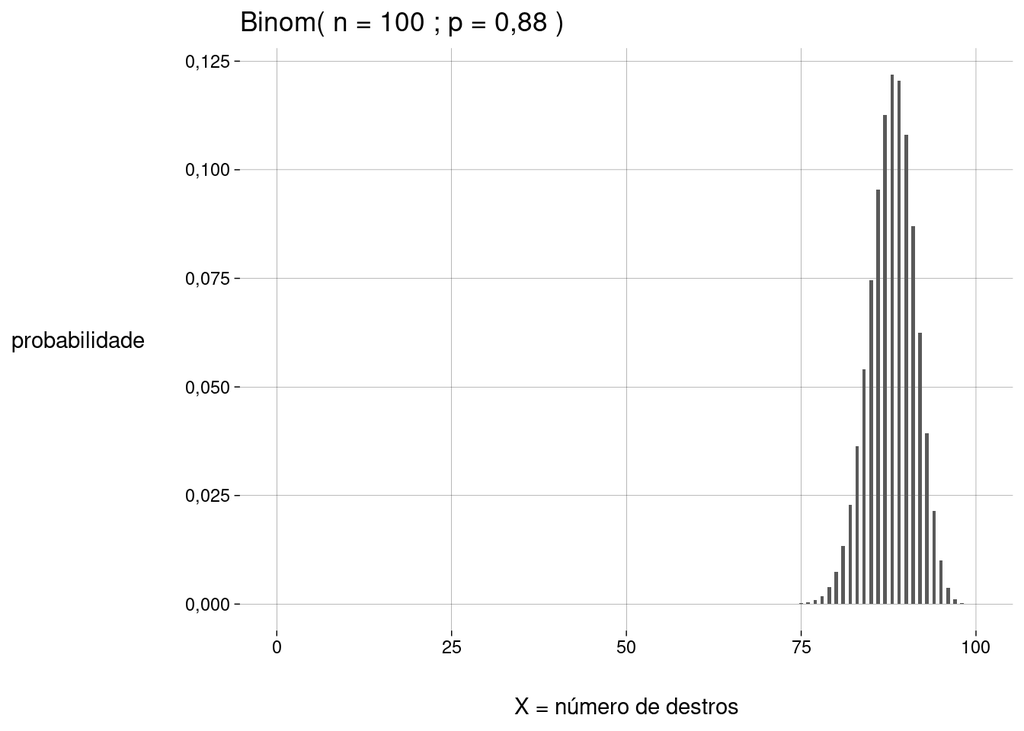

```r
tibble(x = 0:n, prob = dbinom(x, n, p)) %>%
  ggplot(aes(x, prob)) +
    geom_col(width = .5) +
    labs(
      y = 'probabilidade',
      x = 'X = número de destros',
      title = paste('Binom( n =', n, '; p =', p, ')')
    )
```

A probabilidade de alguém ser destro é tão alta que as barras são invisíveis para valores de $X$ abaixo de $75$.